# Conda and Herper

Rockefeller University, Bioinformatics Resource Centre

https://rockefelleruniversity.github.io/RU_reproducibleR/

## What is Conda?

[Conda](https://conda.org/) is an open-source and cross-platform package and environment management system.

It was originally developed to help manage packages for Python, but that has expanded beyond python and is very popular with R users as well.

## How does Conda work?

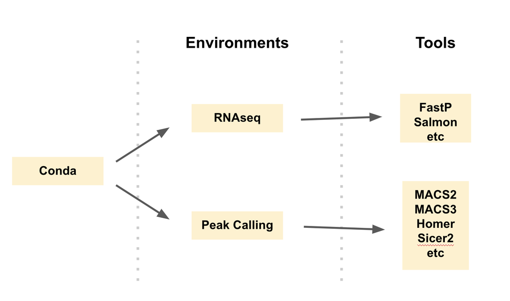

condaoverview

## Why Conda?

- Simplify Package Management
- Cross-Platform Compatibility
- Extensive Package Ecosystem
- Environment Management

## Conda vs miniconda vs …

There are many different repository tools in the Conda ecosystem. They all have slight differences.

Conda - The core package manager

Miniconda - A minimal install of Conda

Anaconda - A maximal install of Conda

Mamba - A reimplementation of Conda built in C++ [FASTER]

Minimamba - A minimal install of Mamba

## A few tips

- Work with miniconda or even better use Herper
- Always install software into new environments (never the base)

## What is Herper

Herper is an R package that provides a simple toolset to install and manage Conda packages and environments from within the R console.

It is built up from the package *reticulate* which is used to run python from within R.

## Installing Tools

The **install_CondaTools()** function allows the user to specify required Conda software and the desired environment to install into.

Miniconda is installed as part of the process (by default into the r-reticulate’s default Conda location - /github/home/.local/share/r-miniconda) and the user’s requested conda environment built within the same directory (by default /github/home/.local/share/r-miniconda/envs/USERS_ENVIRONMENT_HERE).

```r
library(Herper)
install_CondaTools(tools = "star", env = "rnaseq")
```

[output not shown]

## Installing Tools with speicific conda

If you already have Miniconda installed or you would like to install to a custom location, you can specify the path with the *pathToMiniConda* parameter.

```r
my_miniconda <- "~/Desktop/My_Conda"

install_CondaTools(tools = "star", env = "rnaseq", pathToMiniConda = my_miniconda)
```

## Adding more tools

It’s easy to add more tools. You just use *install_CondaTools()* again, but an extra argument also needs to be added: *updateEnv = TRUE*.

By default when we run this command, the path to Conda and the environment is returned. We can save this as a variable for later.

```r
conda_paths <- install_CondaTools(tools = c("salmon", "kallisto"), env = "rnaseq",
    updateEnv = TRUE, pathToMiniConda = my_miniconda)

conda_paths
```

```
$pathToConda
[1] "/Users/mattpaul/Desktop/My_Conda/bin/conda"

$environment
[1] "rnaseq"

$pathToEnvBin
[1] "/Users/mattpaul/Desktop/My_Conda/envs/rnaseq/bin"
```

## Checking packages in an environment

The **list_CondaPkgs** function allows users to check what packages are installed in a given environment.

```r
list_CondaPkgs("rnaseq", pathToMiniConda = my_miniconda)
```

```
boost-cpp         1.78.0      conda-forge   osx-64
bzip2               1.0.8       pkgs/main   osx-64
c-ares            1.19.0        pkgs/main   osx-64
ca-certificates   2023.05.30    pkgs/main   osx-64
hdf5              1.12.2      conda-forge   osx-64
htslib            1.17        bioconda  osx-64
icu               70.1        conda-forge   osx-64
kallisto            0.50.0      bioconda    osx-64
krb5                1.20.1      pkgs/main   osx-64
libaec            1.0.6       conda-forge   osx-64
```

## Finding Conda packages

If the user is unsure of the exact name, or version of a tool available on conda, they can use the **conda_search** function. Searches will find close matches for incorrect queries.

```r
conda_search("kall", pathToMiniConda = my_miniconda)
```

```
There are no exact matches for the query 'kall', but multiple packages contain this text:
- kallisto
- r-merge-kallisto
```

## Finding Conda package versions

If you have the exact name you can search for what versions are available on Conda.

```r
conda_search("kallisto", pathToMiniConda = my_miniconda)
```

```
2   kallisto    0.43.1  https://conda.anaconda.org/bioconda/osx-64
4   kallisto    0.44.0  https://conda.anaconda.org/bioconda/osx-64
5   kallisto    0.45.0  https://conda.anaconda.org/bioconda/osx-64
6   kallisto    0.45.1  https://conda.anaconda.org/bioconda/osx-64
8   kallisto    0.46.0  https://conda.anaconda.org/bioconda/osx-64
9   kallisto    0.46.1  https://conda.anaconda.org/bioconda/osx-64
12  kallisto    0.46.2  https://conda.anaconda.org/bioconda/osx-64
15  kallisto    0.48.0  https://conda.anaconda.org/bioconda/osx-64
16  kallisto    0.50.0  https://conda.anaconda.org/bioconda/osx-64
```

## Finding Conda package versions

Specific package versions can be searched for using the Conda format i.e. “kallisto==0.46”, “kallisto>=0.48” or “kallisto<=0.45”.

```r
conda_search("kallisto<=0.45", pathToMiniConda = my_miniconda)
```

```
2   kallisto    0.43.1  https://conda.anaconda.org/bioconda/osx-64
4   kallisto    0.44.0  https://conda.anaconda.org/bioconda/osx-64
```

## Installing specific versions

We can use the same version nomenclature to also install these tools. Here we will downgrade the version of Kallisto we have installed.

```r
conda_paths <- install_CondaTools(tools = "kallisto<=0.45", env = "rnaseq", updateEnv = T,
    pathToMiniConda = my_miniconda)
```

## Installing specific versions

We can now see that we have downgraded Kallisto.

```r
library(magrittr)
library(dplyr)
list_CondaPkgs("rnaseq", pathToMiniConda = my_miniconda) %>%
    dplyr::filter(name == "kallisto")
```

[output not shown]

## Running software

Once installed within a Conda environment, many external software can be executed directly from the Conda environment’s bin directory without having to perform any additional actions.

The Herper package uses the **[withr](https://withr.r-lib.org)** family of functions (**with_CondaEnv()** and **local_CondaEnv()**) to provide methods to **temporarily** alter the system PATH and to add or update any required environmental variables. This is done without formally activating your environment or initializing your conda.

## **with_CondaEnv**

The **with_CondaEnv** allows users to run R code with the required PATH and environmental variables automatically set. The **with_CondaEnv** function simply requires the name of conda environment and the code to be executed within this environment. Additionally we can also the **pathToMiniconda** argument to specify any custom miniconda install location.

Here we use the **with_CondaEnv** to allow us to *see* the tools installed in out our “rnaseq” environment. We can then use the R function *system2()* to run some terminal/command line code from within R. In this case we want to run the salmon help.

```r
res <- with_CondaEnv("rnaseq",
                      system2(command="salmon",args = "help",stdout = TRUE),
                      pathToMiniConda=my_miniconda)
res
```

```
 [1] "salmon v1.10.2"
 [2] ""
 [3] "Usage:  salmon -h|--help or "
 [4] "        salmon -v|--version or "
 [5] "        salmon -c|--cite or "
 [6] "        salmon [--no-version-check] <COMMAND> [-h | options]"
 [7] ""
 [8] "Commands:"
 [9] "     index      : create a salmon index"
[10] "     quant      : quantify a sample"
[11] "     alevin     : single cell analysis"
[12] "     swim       : perform super-secret operation"
[13] "     quantmerge : merge multiple quantifications into a single file"
```

## **local_CondaEnv**

The **local_CondaEnv** function acts in a similar fashion to the **with_CondaEnv** function: it will update the required PATH and environmental variable so you can access the tools you need. The PATH and environmental variables will persist though until the current function ends.

**local_CondaEnv** is best used within a user-created function, allowing access to the Conda environment’s PATH and variables from within the the function itself but resetting all environmental variables once complete.

```r
salmonHelp <- function() {
    local_CondaEnv("rnaseq", pathToMiniConda = my_miniconda)
    helpMessage <- system2(command = "salmon", args = "help", stdout = TRUE)
    helpMessage
}
salmonHelp()
```

```
 [1] "salmon v1.10.2"
 [2] ""
 [3] "Usage:  salmon -h|--help or "
 [4] "        salmon -v|--version or "
 [5] "        salmon -c|--cite or "
 [6] "        salmon [--no-version-check] <COMMAND> [-h | options]"
 [7] ""
 [8] "Commands:"
 [9] "     index      : create a salmon index"
[10] "     quant      : quantify a sample"
[11] "     alevin     : single cell analysis"
[12] "     swim       : perform super-secret operation"
[13] "     quantmerge : merge multiple quantifications into a single file"
```

## Reproducible environments

Once you are done you have an environment that is functioning well you will want to save it. One way to back it up is to export a snapshot. For Conda this snapshot is a *.yml* file. These files contain all information about the environment you would need in order to rebuild or share it for collaboration.

```r
yml_name <- paste0("rnaseq_", format(Sys.Date(), "%Y%m%d"), ".yml")
export_CondaEnv("rnaseq", yml_name, pathToMiniConda = my_miniconda)
```

## Our *.yml* file

The yml that is output contains all the information you need to rebuild the environment. This is also a a nice resource for when it comes to writing your methods.

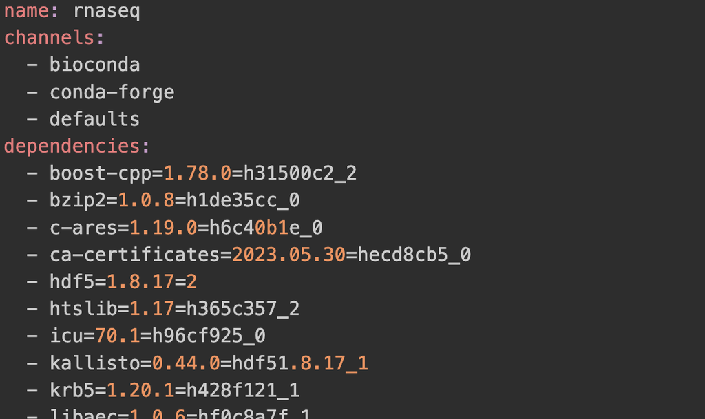

yml

## Importing from *.yml*

The **import_CondaEnv** function allows the user to create a new conda environment from a *.yml* file. These can be previously exported from **export_CondaEnv**, conda, renv or manually created.

Users can simply provide a path to the YAML file for import. They can also specify the environment name, but by default the name will be taken from the YAML.

```r
testYML <- system.file("extdata/test.yml", package = "Herper")
import_CondaEnv(yml_import = testYML, pathToMiniConda = my_miniconda)
```

## Other tricks

- **Verbosity** - We can Herper either very chatty or compltely silent using the *verbose* argument. This is especially useful for troubleshooting or building pipelines.
- **list_CondaEnv()** - This will list every version of Conda, and every environment you have installed.
- **Mamba** - This will speed up your Conda. We are in the process of adding an option that will allow you to use Mamba resolution with Herper.

## What about Pip?

Pip is an alternative system to install python tools. But it typically only works with python tools.

Pip doesn’t handle conflicting dependencies, and will upgrade/downgrade software without checking if something else depends on it.

Even if this doesn’t break your tools, it may give different results and hinder reproducibility as unsupported versions of tools could be used.

Conda is much more considered, and checks installs to make sure that all your dependencies do not conflict.

## Why use Pip?

- Not very Conda build is perfect
- Not every tool is on Conda

Sometimes we have to use pip. But that does not mean we have to leave our environment behind.

## Pip install

First we need to mkae sure we have pip installed. Oftent his is not the case in new environments. Then we provide the direct path to our command and the isntall should run.

```r
install_CondaTools("pip", "rnaseq", pathToMiniConda = my_miniconda, updateEnv = TRUE)

with_CondaEnv("rnaseq", system2(command = paste0(conda_paths$pathToEnvBin, "/pip"),
    args = c("install", "scanpy"), stdout = TRUE), pathToMiniConda = my_miniconda)
```

## Check envs

```r
list_CondaPkgs("rnaseq", pathToMiniConda = my_miniconda) %>%
    dplyr::filter(name == "scanpy")
```

```
scanpy  1.9.3   pypi    pypi
```

## Further Resources

- The Herper [guide](https://rockefelleruniversity.github.io/Herper_Page/)
- The Anaconda package [directory](https://anaconda.org/anaconda/repo)

## Exercises

Exercise on Conda and Herper can be found here

## Contact

Any suggestions, comments, edits or questions (about content or the slides themselves) please reach out to our [GitHub](https://github.com/RockefellerUniversity/Reproducible_R/issues) and raise an issue.